# Group_Project_(NEW)

```python
import pandas as pd
import numpy as np
from matplotlib import pyplot as plt
import seaborn as sns
from scipy.stats import chi2_contingency

from wordcloud import WordCloud, STOPWORDS
import PIL.Image

from sklearn.preprocessing import StandardScaler
from sklearn.neighbors import KNeighborsClassifier

from sklearn.model_selection import train_test_split
from sklearn.svm import SVC
from sklearn.neural_network import MLPClassifier
from sklearn.tree import DecisionTreeClassifier
from sklearn import tree
from sklearn.naive_bayes import MultinomialNB
from sklearn.metrics import classification_report
from sklearn.metrics import confusion_matrix, ConfusionMatrixDisplay

from sklearn import linear_model
from sklearn.metrics import mean_squared_error, r2_score
```

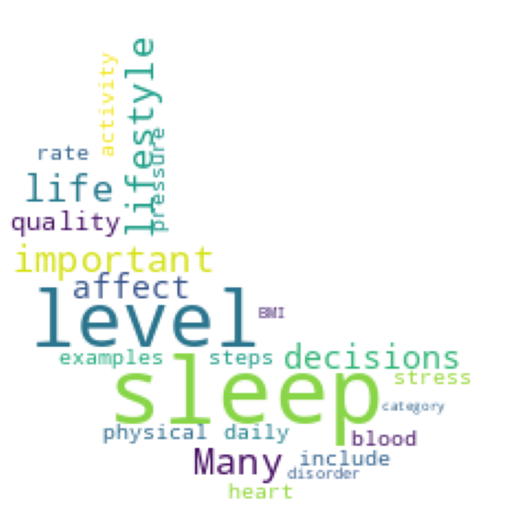

```python
text = open('sleep.txt','r').read()
pic_python = np.array(PIL.Image.open('Moon.jpg'))
plt.figure(figsize=(8,8))
wc = WordCloud(mask=pic_python, background_color='white').generate(text)
plt.imshow(wc)
plt.axis('off')
plt.show()
```

The above word cloud is in the shape of a moon, which represents our topic today: **sleep**

### Why is sleep important?

Sleep improves your brain performance, mood, and health. Not getting enough sleep can increase your chances for heart disease, stroke, obesity, and dementia. Interestingly, the brain removes toxins while we sleep. [2]

### How much sleep should you be getting per night?

The recommended amount per night for adults is 7 or more hours. [1]

### Abstract:

First, we tried to understand the characteristics of our sample. We accomplished this via data preprocessing and data visualizations. Then, we created a linear regression model to predict sleep duration based on various factors. After, we used the decision tree model to predict sleep disorder based on certain variables. Lastly, we used the Naive Bayes, KNN, Support Vector Machine, and Neural Network models to predict one's sleep quality based on their lifestyle. By the end of the project, we concluded some research and practical applications. We also concluded the best model based on their classification reports.

### Task 1: Load data set into 'df' and understand the variables we are working with

```python
df = pd.read_csv('sleep.csv')
df.head()
```

|  | Person ID | Gender | Age | Occupation | Sleep Duration | Quality of Sleep | Physical Activity Level | Stress Level | BMI Category | Blood Pressure | Heart Rate | Daily Steps | Sleep Disorder |
| --- | --- | --- | --- | --- | --- | --- | --- | --- | --- | --- | --- | --- | --- |
| 0 | 1 | Male | 27 | Software Engineer | 6.1 | 6 | 42 | 6 | Overweight | 126/83 | 77 | 4200 | None |
| 1 | 2 | Male | 28 | Doctor | 6.2 | 6 | 60 | 8 | Normal | 125/80 | 75 | 10000 | None |
| 2 | 3 | Male | 28 | Doctor | 6.2 | 6 | 60 | 8 | Normal | 125/80 | 75 | 10000 | None |
| 3 | 4 | Male | 28 | Sales Representative | 5.9 | 4 | 30 | 8 | Overweight | 140/90 | 85 | 3000 | Sleep Apnea |
| 4 | 5 | Male | 28 | Sales Representative | 5.9 | 4 | 30 | 8 | Overweight | 140/90 | 85 | 3000 | Sleep Apnea |

1. Person ID: An identifier for each individual.
2. Gender: The gender of the person (Male/Female).
3. Age: The age of the person in years.
4. Occupation: The job of the person.
5. Sleep Duration (hours): The number of hours the person sleeps per day.
6. Quality of Sleep (scale: 1-10): A subjective rating of the quality of sleep, ranging from 1 to 10.
7. Physical Activity Level (minutes/day): The number of minutes the person engages in physical activity daily.
8. Stress Level (scale: 1-10): A subjective rating of the stress level experienced by the person, ranging from 1 to 10.
9. BMI Category: The BMI category of the person (e.g., Underweight, Normal, Overweight)
10. Blood Pressure (systolic/diastolic): The blood pressure measurement of the person, indicated as systolic pressure over diastolic pressure.
11. Heart Rate (bpm): The resting heart rate of the person in beats per minute.
12. Daily Steps: The number of steps the person takes per day.
13. Sleep Disorder: The presence or absence of a sleep disorder in the person (None - the individual does not exhibit any specific sleep disorder; Insomnia - the individual experiences difficulty falling asleep or staying asleep, leading to inadequate or poor-quality sleep; Sleep Apnea - the individual suffers from pauses in breathing during sleep, resulting in disrupted sleep patterns and potential health risks.)

### Task 2: Check how many rows and columns the data set has

```python
df.shape
```

```
(374, 13)
```

This means that there are 374 samples of people with 13 characteristics to describe each person.

### Task 3: Create a bar chart for BMI category across gender

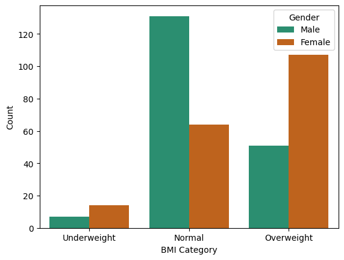

```python
sns.countplot(data = df, x ='BMI Category',order=['Underweight','Normal','Overweight'],hue='Gender',palette= 'Dark2')
plt.ylabel('Count')
plt.show()
```

Most people have a normal or overweight BMI. Females are more likely to be overweight than males, while the males are more likely to be normal weight than women. When it comes to being underweight, there are more women than men.

```python
sum(df['Gender']== 'Male')
```

```
189
```

```python
sum(df['Gender']== 'Female')
```

```
185
```

Male and female are split almost evenly in this data set.

### Task 4: Create a pie chart to understand the distribution of sleep disorders among this sample

```python
df['Sleep Disorder'].value_counts()
```

```
None           219
Sleep Apnea     78
Insomnia        77
Name: Sleep Disorder, dtype: int64
```

```python
disorder_names = df['Sleep Disorder'].value_counts().index.tolist()
disorder_names
```

```
['None', 'Sleep Apnea', 'Insomnia']
```

```python
disorder_values = df['Sleep Disorder'].value_counts().tolist()
disorder_values
```

```
[219, 78, 77]
```

```python
disorder_colors = ['#335c67', '#fff3b0', '#e09f3e', '#9e2a2b', '#540b0e']
```

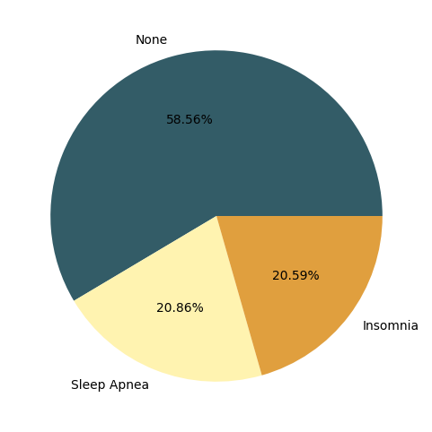

```python
fig = plt.figure(figsize=(6, 6))
plt.pie(disorder_values, labels=disorder_names, colors = disorder_colors, autopct='%1.2f%%')
plt.show()
```

The pie chart helps us understand that more than half of the sample (58.56%) has no sleep disorder and about 40% has either Sleep Apnea or Insomnia.

### Task 5: Create histograms to show the distribution of age, sleep duration, physical activity level, and daily steps

```python
hist_df = df.iloc[:, [2,4,6,11]]
hist_df.head()
```

|  | Age | Sleep Duration | Physical Activity Level | Daily Steps |
| --- | --- | --- | --- | --- |
| 0 | 27 | 6.1 | 42 | 4200 |
| 1 | 28 | 6.2 | 60 | 10000 |
| 2 | 28 | 6.2 | 60 | 10000 |
| 3 | 28 | 5.9 | 30 | 3000 |
| 4 | 28 | 5.9 | 30 | 3000 |

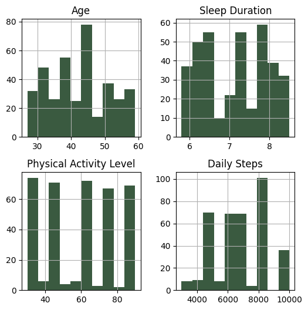

```python
hist_df.hist(figsize=(6,6), color='#3a5a40')
plt.show()
```

The age histogram shows an age range from late 20's to late 50's, with the majority of individuals around 45 years old. The next most common ages are approximately 38 and 32, while the least represented age is around 48.

Regarding the sleep duration histogram, a notable observation is that a significant portion of individuals tends to sleep around 6 to 6.5 hours, 7 hours, and 8 hours.

In terms of the daily steps histogram, the majority of people take between 5000 to 8000 steps. Overall, this provides valuable insights into the general patterns and distribution of these key health-related variables.

### Task 6: Conduct a chi-square test to uncover the correlation between quality of sleep and stress level

```python
quality_of_sleep_bins = [1, 4, 7, 10]
quality_of_sleep_labels = ['Low', 'Medium', 'High']
df['Quality_of_Sleep_Levels'] = pd.cut(df['Quality of Sleep'], bins = quality_of_sleep_bins,
                                       labels = quality_of_sleep_labels, right = False)
df.head()
```

[output not shown]

```python
stress_level_bins = [1, 4, 7, 10]
stress_labels = ['Low', 'Medium', 'High']
df['Stress_Levels'] = pd.cut(df['Stress Level'], bins = stress_level_bins, labels = stress_labels, right = False)
df.head()
```

|  | Person ID | Gender | Age | Occupation | Sleep Duration | Quality of Sleep | Physical Activity Level | Stress Level | BMI Category | Blood Pressure | Heart Rate | Daily Steps | Sleep Disorder | Quality_of_Sleep_Levels | Stress_Levels |
| --- | --- | --- | --- | --- | --- | --- | --- | --- | --- | --- | --- | --- | --- | --- | --- |
| 0 | 1 | Male | 27 | Software Engineer | 6.1 | 6 | 42 | 6 | Overweight | 126/83 | 77 | 4200 | None | Medium | Medium |
| 1 | 2 | Male | 28 | Doctor | 6.2 | 6 | 60 | 8 | Normal | 125/80 | 75 | 10000 | None | Medium | High |
| 2 | 3 | Male | 28 | Doctor | 6.2 | 6 | 60 | 8 | Normal | 125/80 | 75 | 10000 | None | Medium | High |
| 3 | 4 | Male | 28 | Sales Representative | 5.9 | 4 | 30 | 8 | Overweight | 140/90 | 85 | 3000 | Sleep Apnea | Medium | High |
| 4 | 5 | Male | 28 | Sales Representative | 5.9 | 4 | 30 | 8 | Overweight | 140/90 | 85 | 3000 | Sleep Apnea | Medium | High |

```python
contingency_table = pd.crosstab(df['Quality_of_Sleep_Levels'], df['Stress_Levels'])
contingency_table
```

| Stress_Levels Quality_of_Sleep_Levels | Low | Medium | High |
| --- | --- | --- | --- |
| Medium | 0 | 4 | 113 |
| High | 71 | 179 | 7 |

```python
chi2_score, p_value, dof, _ = chi2_contingency(contingency_table)
chi2_score, p_value, dof
```

```
(325.1360414034969, 2.4980761629963486e-71, 2)
```

```python
round(p_value,3)
```

```
0.0
```

Based on the p value, there is a strong association between quality of sleep and stress level and it is statistically significant.

### Task 7: Create a KDE plot of sleep duration by BMI category

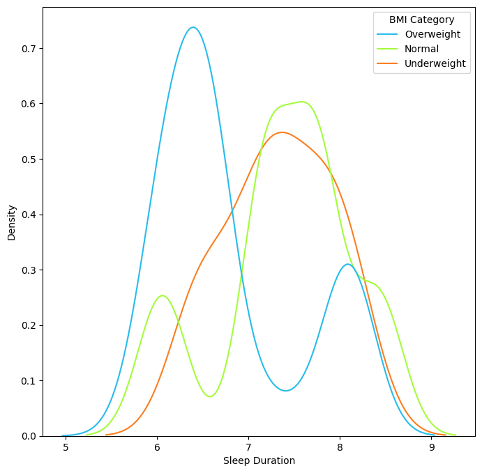

```python
plt.figure(figsize=(8,8))
sns.kdeplot(data=df,x='Sleep Duration', hue='BMI Category', palette='turbo', common_norm=False)
plt.show()
```

This kde plot shows that a majority of people within the normal BMI category tend to have a high sleep duration of about 7.5 hours. Also, a majority of people within the overweight BMI category tend to have a lower sleep duration of 6 hours. Interestingly, the people who fall within the underweight BMI category have a good sleep duration of 7.5 hours.

### Task 8: Create a heatmap to uncover correlation between lifestyle variables and sleep

```python
numeric_df = df[['Sleep Duration', 'Age', 'Quality of Sleep', 'Physical Activity Level',
                 'Stress Level', 'Blood Pressure', 'Heart Rate', 'Daily Steps']]
numeric_df.head()
```

|  | Sleep Duration | Age | Quality of Sleep | Physical Activity Level | Stress Level | Blood Pressure | Heart Rate | Daily Steps |
| --- | --- | --- | --- | --- | --- | --- | --- | --- |
| 0 | 6.1 | 27 | 6 | 42 | 6 | 126/83 | 77 | 4200 |
| 1 | 6.2 | 28 | 6 | 60 | 8 | 125/80 | 75 | 10000 |
| 2 | 6.2 | 28 | 6 | 60 | 8 | 125/80 | 75 | 10000 |
| 3 | 5.9 | 28 | 4 | 30 | 8 | 140/90 | 85 | 3000 |
| 4 | 5.9 | 28 | 4 | 30 | 8 | 140/90 | 85 | 3000 |

```python
corr = numeric_df.corr()
corr
```

|  | Sleep Duration | Age | Quality of Sleep | Physical Activity Level | Stress Level | Heart Rate | Daily Steps |
| --- | --- | --- | --- | --- | --- | --- | --- |
| Sleep Duration | 1.000000 | 0.344709 | 0.883213 | 0.212360 | -0.811023 | -0.516455 | -0.039533 |
| Age | 0.344709 | 1.000000 | 0.473734 | 0.178993 | -0.422344 | -0.225606 | 0.057973 |
| Quality of Sleep | 0.883213 | 0.473734 | 1.000000 | 0.192896 | -0.898752 | -0.659865 | 0.016791 |
| Physical Activity Level | 0.212360 | 0.178993 | 0.192896 | 1.000000 | -0.034134 | 0.136971 | 0.772723 |
| Stress Level | -0.811023 | -0.422344 | -0.898752 | -0.034134 | 1.000000 | 0.670026 | 0.186829 |
| Heart Rate | -0.516455 | -0.225606 | -0.659865 | 0.136971 | 0.670026 | 1.000000 | -0.030309 |
| Daily Steps | -0.039533 | 0.057973 | 0.016791 | 0.772723 | 0.186829 | -0.030309 | 1.000000 |

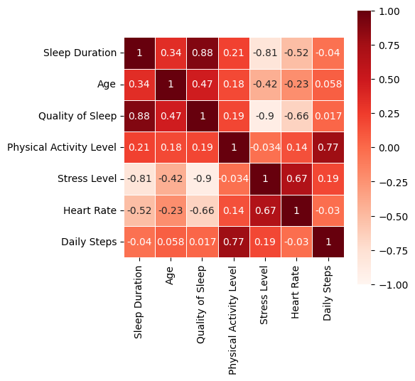

```python
plt.figure(figsize=(5,5))
sns.heatmap(corr, square=True, linewidth=0.5, vmin=-1, vmax=1,cmap='Reds',
            annot=True)
plt.show()
```

This heatmap shows how there is a strong positive correlation between quality of sleep and sleep duration. As you sleep more hours in the night, your quality of sleep increases and vice versa. Also, there is a strong negative correlation between stress level and sleep duration/quality of sleep. The more stress you have in your life, the less hours of sleep you may get and vice versa. Also, the more stress you have in your life, the lower your sleep quality is and vice versa.

### Task 9: Create a swarmplot to show the distribution of sleep duration upon physical activity

```python
sub_df = df.sample(frac=0.2)
len(sub_df)
```

```
75
```

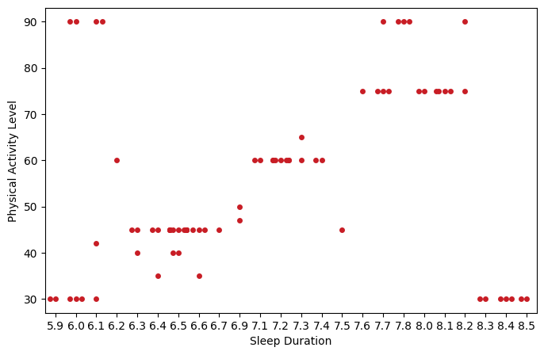

```python
plt.figure(figsize=(8,5))
sns.swarmplot(sub_df, x='Sleep Duration', y='Physical Activity Level', color='#C81D25')
plt.show()
```

### Task 10: Create a Linear Regression model to predict sleep duration based on daily steps, BMI category, sleep disorder, gender, and age

```python
lrfeature_set = df[['Daily Steps', 'BMI Category', 'Sleep Disorder', 'Gender', 'Age']]
lrfeature_set.head()
```

|  | Daily Steps | BMI Category | Sleep Disorder | Gender | Age |
| --- | --- | --- | --- | --- | --- |
| 0 | 4200 | Overweight | None | Male | 27 |
| 1 | 10000 | Normal | None | Male | 28 |
| 2 | 10000 | Normal | None | Male | 28 |
| 3 | 3000 | Overweight | Sleep Apnea | Male | 28 |
| 4 | 3000 | Overweight | Sleep Apnea | Male | 28 |

```python
d_fs = pd.get_dummies(lrfeature_set, columns=['BMI Category', 'Sleep Disorder','Gender'],
                      drop_first=True)
d_fs.head()
```

|  | Daily Steps | Age | BMI Category_Overweight | BMI Category_Underweight | Sleep Disorder_None | Sleep Disorder_Sleep Apnea | Gender_Male |
| --- | --- | --- | --- | --- | --- | --- | --- |
| 0 | 4200 | 27 | 1 | 0 | 1 | 0 | 1 |
| 1 | 10000 | 28 | 0 | 0 | 1 | 0 | 1 |
| 2 | 10000 | 28 | 0 | 0 | 1 | 0 | 1 |
| 3 | 3000 | 28 | 1 | 0 | 0 | 1 | 1 |
| 4 | 3000 | 28 | 1 | 0 | 0 | 1 | 1 |

```python
lr_label = df[['Sleep Duration']]
lr_label.head()
```

|  | Sleep Duration |
| --- | --- |
| 0 | 6.1 |
| 1 | 6.2 |
| 2 | 6.2 |
| 3 | 5.9 |
| 4 | 5.9 |

```python
lrtrain_x, lrtest_x, lrtrain_y, lrtest_y = train_test_split(d_fs,lr_label, test_size=0.2,
                                                    random_state=42)
```

```python
regr = linear_model.LinearRegression()
regr.fit(lrtrain_x, lrtrain_y)
```

```
LinearRegression()
```

```python
lrpred_y = regr.predict(lrtest_x)
```

```python
mean_squared_error(lrtest_y, lrpred_y)
```

```
0.36985227640769414
```

```python
r2_score(lrtest_y, lrpred_y)
```

```
0.4444749597343417
```

```python
d_fs.head()
```

|  | Daily Steps | Age | BMI Category_Overweight | BMI Category_Underweight | Sleep Disorder_None | Sleep Disorder_Sleep Apnea | Gender_Male |
| --- | --- | --- | --- | --- | --- | --- | --- |
| 0 | 4200 | 27 | 1 | 0 | 1 | 0 | 1 |
| 1 | 10000 | 28 | 0 | 0 | 1 | 0 | 1 |
| 2 | 10000 | 28 | 0 | 0 | 1 | 0 | 1 |
| 3 | 3000 | 28 | 1 | 0 | 0 | 1 | 1 |
| 4 | 3000 | 28 | 1 | 0 | 0 | 1 | 1 |

```python
emily = [[2000, 21, 0, 0, 1, 0, 0]]

regr.predict(emily)
```

```
array([[6.3873633]])
```

### Task 11: Create a Decision Tree to predict if a person has a sleep disorder based on their physical activity level, stress level, BMI category, and daily steps

```python
df.head()
```

|  | Person ID | Gender | Age | Occupation | Sleep Duration | Quality of Sleep | Physical Activity Level | Stress Level | BMI Category | Blood Pressure | Heart Rate | Daily Steps | Sleep Disorder | Quality_of_Sleep_Levels | Stress_Levels |
| --- | --- | --- | --- | --- | --- | --- | --- | --- | --- | --- | --- | --- | --- | --- | --- |
| 0 | 1 | Male | 27 | Software Engineer | 6.1 | 6 | 42 | 6 | Overweight | 126/83 | 77 | 4200 | None | Medium | Medium |
| 1 | 2 | Male | 28 | Doctor | 6.2 | 6 | 60 | 8 | Normal | 125/80 | 75 | 10000 | None | Medium | High |
| 2 | 3 | Male | 28 | Doctor | 6.2 | 6 | 60 | 8 | Normal | 125/80 | 75 | 10000 | None | Medium | High |
| 3 | 4 | Male | 28 | Sales Representative | 5.9 | 4 | 30 | 8 | Overweight | 140/90 | 85 | 3000 | Sleep Apnea | Medium | High |
| 4 | 5 | Male | 28 | Sales Representative | 5.9 | 4 | 30 | 8 | Overweight | 140/90 | 85 | 3000 | Sleep Apnea | Medium | High |

```python
dt_label = df.iloc[:, 12]
```

```python
dt_label.replace('Sleep Apnea', 'Yes', inplace=True)
dt_label.replace('Insomnia', 'Yes', inplace=True)
dt_label.value_counts()
```

```
None    219
Yes     155
Name: Sleep Disorder, dtype: int64
```

```python
dt_feature = df.iloc[:, [6,7,8,11]]
dt_feature.head()
```

|  | Physical Activity Level | Stress Level | BMI Category | Daily Steps |
| --- | --- | --- | --- | --- |
| 0 | 42 | 6 | Overweight | 4200 |
| 1 | 60 | 8 | Normal | 10000 |
| 2 | 60 | 8 | Normal | 10000 |
| 3 | 30 | 8 | Overweight | 3000 |
| 4 | 30 | 8 | Overweight | 3000 |

```python
dt_feature = pd.get_dummies(dt_feature, columns=['BMI Category'], drop_first=True)
dt_feature.head()
```

|  | Physical Activity Level | Stress Level | Daily Steps | BMI Category_Overweight | BMI Category_Underweight |
| --- | --- | --- | --- | --- | --- |
| 0 | 42 | 6 | 4200 | 1 | 0 |
| 1 | 60 | 8 | 10000 | 0 | 0 |
| 2 | 60 | 8 | 10000 | 0 | 0 |
| 3 | 30 | 8 | 3000 | 1 | 0 |
| 4 | 30 | 8 | 3000 | 1 | 0 |

```python
dt_scaler_1 = StandardScaler()
columns_to_standardization = ['Physical Activity Level', 'Stress Level', 'Daily Steps', 'BMI Category_Overweight', 'BMI Category_Underweight']
dt_feature[columns_to_standardization] = dt_scaler_1.fit_transform(dt_feature[columns_to_standardization])
dt_feature[columns_to_standardization] = dt_feature[columns_to_standardization].round(2)
dt_feature.head()
```

|  | Physical Activity Level | Stress Level | Daily Steps | BMI Category_Overweight | BMI Category_Underweight |
| --- | --- | --- | --- | --- | --- |
| 0 | -0.83 | 0.35 | -1.62 | 1.17 | -0.24 |
| 1 | 0.04 | 1.48 | 1.97 | -0.86 | -0.24 |
| 2 | 0.04 | 1.48 | 1.97 | -0.86 | -0.24 |
| 3 | -1.40 | 1.48 | -2.36 | 1.17 | -0.24 |
| 4 | -1.40 | 1.48 | -2.36 | 1.17 | -0.24 |

```python
dt_train_x, dt_test_x, dt_train_y, dt_test_y = train_test_split(dt_feature, dt_label, test_size=0.2, random_state=20)
len(dt_train_x), len(dt_test_x), len(dt_train_y), len(dt_test_y)
```

```
(299, 75, 299, 75)
```

```python
dt_model = DecisionTreeClassifier()
dt_model.fit(dt_train_x, dt_train_y)
```

```
DecisionTreeClassifier()
```

```python
dt_prediction = dt_model.predict(dt_test_x)
```

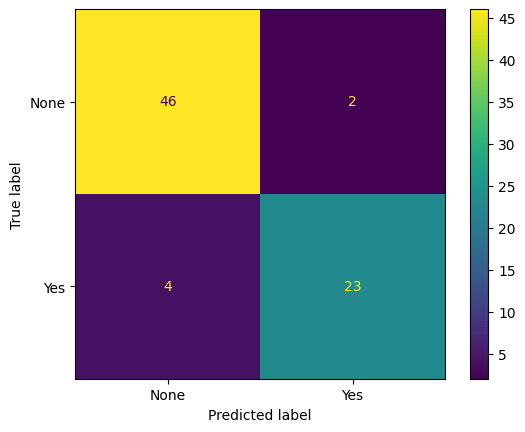

```python
dt_cm = confusion_matrix(dt_test_y, dt_prediction, labels=dt_model.classes_)
dt_cmd = ConfusionMatrixDisplay(dt_cm, display_labels=dt_model.classes_)
dt_cmd.plot()
plt.show()
```

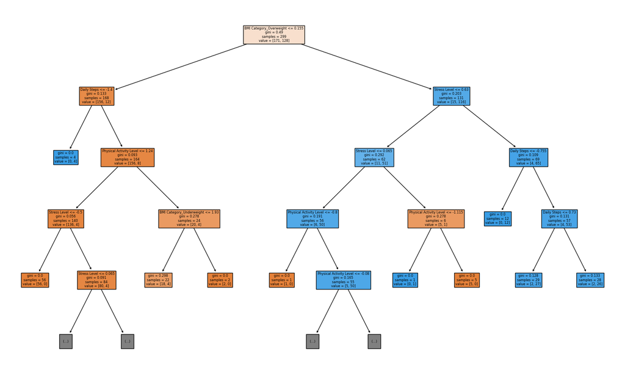

```python
plt.figure(figsize=(20,12))
tree.plot_tree(dt_model, feature_names=list(dt_train_x), filled=True, max_depth=4)
plt.show()
```

```python
dt_report = classification_report(dt_test_y,dt_prediction)
print(dt_report)
```

```
              precision    recall  f1-score   support

        None       0.92      0.96      0.94        48
         Yes       0.92      0.85      0.88        27

    accuracy                           0.92        75
   macro avg       0.92      0.91      0.91        75
weighted avg       0.92      0.92      0.92        75
```

The label "yes" means that the individual has a sleep disorder, either Sleep Apnea or Insomnia. The lable "none" means that they don't have a sleep disorder. In our decision tree model, we achieved an overall accuracy of 92%, indicating robust performance. Specifically, the precision for both classes was 92%, meaning the number of false positives is low. The high recall percentages indicate a lower number of false negatives. High precision, recall, and accuracy underscores the model's effectiveness in correctly identifying cases of interest.

### Task 12: Create a Naive Bayes model to predict sleep quality using all variables except blood pressure, person ID, and occupation

```python
nb_label = df['Quality of Sleep']
nb_label.head()
```

```
0    6
1    6
2    6
3    4
4    4
Name: Quality of Sleep, dtype: int64
```

```python
nb_feature = df.drop(['Person ID','Blood Pressure','Quality of Sleep', 'Occupation'],axis=1)
nb_feature.head()
```

|  | Gender | Age | Sleep Duration | Physical Activity Level | Stress Level | BMI Category | Heart Rate | Daily Steps | Sleep Disorder |
| --- | --- | --- | --- | --- | --- | --- | --- | --- | --- |
| 0 | Male | 27 | 6.1 | 42 | 6 | Overweight | 77 | 4200 | None |
| 1 | Male | 28 | 6.2 | 60 | 8 | Normal | 75 | 10000 | None |
| 2 | Male | 28 | 6.2 | 60 | 8 | Normal | 75 | 10000 | None |
| 3 | Male | 28 | 5.9 | 30 | 8 | Overweight | 85 | 3000 | Sleep Apnea |
| 4 | Male | 28 | 5.9 | 30 | 8 | Overweight | 85 | 3000 | Sleep Apnea |

```python
nb_feature = pd.get_dummies(data=nb_feature,
                            columns=['Gender','Stress Level','BMI Category'
                            ,'Sleep Disorder'],drop_first=True)
nb_feature.head()
```

|  | Age | Sleep Duration | Physical Activity Level | Heart Rate | Daily Steps | Gender_Male | Stress Level_4 | Stress Level_5 | Stress Level_6 | Stress Level_7 | Stress Level_8 | BMI Category_Overweight | BMI Category_Underweight | Sleep Disorder_None | Sleep Disorder_Sleep Apnea |
| --- | --- | --- | --- | --- | --- | --- | --- | --- | --- | --- | --- | --- | --- | --- | --- |
| 0 | 27 | 6.1 | 42 | 77 | 4200 | 1 | 0 | 0 | 1 | 0 | 0 | 1 | 0 | 1 | 0 |
| 1 | 28 | 6.2 | 60 | 75 | 10000 | 1 | 0 | 0 | 0 | 0 | 1 | 0 | 0 | 1 | 0 |
| 2 | 28 | 6.2 | 60 | 75 | 10000 | 1 | 0 | 0 | 0 | 0 | 1 | 0 | 0 | 1 | 0 |
| 3 | 28 | 5.9 | 30 | 85 | 3000 | 1 | 0 | 0 | 0 | 0 | 1 | 1 | 0 | 0 | 1 |
| 4 | 28 | 5.9 | 30 | 85 | 3000 | 1 | 0 | 0 | 0 | 0 | 1 | 1 | 0 | 0 | 1 |

```python
nb_train_x, nb_test_x, nb_train_y, nb_test_y = train_test_split(nb_feature, nb_label, test_size=0.2, random_state=24)
```

```python
NB_model = MultinomialNB()
NB_model.fit(nb_train_x, nb_train_y)
```

```
MultinomialNB()
```

```python
nb_pred_y = NB_model.predict(nb_test_x)
nb_pred_y
```

```
array([8, 8, 6, 6, 6, 8, 6, 6, 9, 8, 8, 6, 8, 8, 8, 5, 8, 6, 9, 6, 9, 8,
       9, 8, 8, 7, 8, 7, 8, 8, 6, 5, 6, 6, 6, 7, 8, 6, 9, 9, 7, 8, 8, 8,
       6, 8, 6, 6, 9, 6, 5, 6, 6, 8, 8, 8, 6, 7, 6, 7, 9, 6, 8, 9, 7, 8,
       6, 6, 8, 8, 6, 8, 6, 4, 9])
```

```python
nb_report = classification_report(nb_test_y,nb_pred_y)
print(nb_report)
```

```
              precision    recall  f1-score   support

           4       1.00      1.00      1.00         1
           5       0.67      1.00      0.80         2
           6       0.96      0.96      0.96        26
           7       0.71      0.42      0.53        12
           8       0.75      0.88      0.81        24
           9       1.00      1.00      1.00        10

    accuracy                           0.85        75
   macro avg       0.85      0.88      0.85        75
weighted avg       0.85      0.85      0.84        75
```

The classification report provides detailed performance metrics for a sleep quality prediction model that ranges from 1-10 (in this case, 4 to 9 because 1-3 and 10 are not represented). For sleep quality levels 4 and 9, precision, recall, and f1-score are all perfect (1.00), indicating flawless predictions for those levels. Level 5 shows lower precision and f1-score, suggesting that the model struggles to accurately classify instances of this less common level. Levels 6 and 8 have high precision, recall, and f1-score. Level 7 has lower scores for each measure. The overall accuracy is 85%, but considering the imbalanced distribution of sleep quality levels in the dataset, it's crucial to assess class-specific metrics. The macro and weighted averages provide aggregated insights, with macro avg considering each class equally and weighted avg accounting for class imbalance. The value counts show that levels 6 and 8 are more common, potentially influencing the overall accuracy, and emphasizing the importance of examining class-specific metrics for a comprehensive evaluation of the model's performance. Regardless, the precision, recall, and f-1 scores show very good predictive power using the Naive Bayes model.

### Task 13: Create a KNN model to predict sleep quality using all variables except blood pressure, person ID, and occupation

```python
knn_label = df['Quality of Sleep']
knn_label.head()
```

```
0    6
1    6
2    6
3    4
4    4
Name: Quality of Sleep, dtype: int64
```

```python
knn_feature = df.drop(['Person ID','Blood Pressure', 'Quality of Sleep', 'Occupation'],axis=1)
knn_feature.head()
```

|  | Gender | Age | Sleep Duration | Physical Activity Level | Stress Level | BMI Category | Heart Rate | Daily Steps | Sleep Disorder |
| --- | --- | --- | --- | --- | --- | --- | --- | --- | --- |
| 0 | Male | 27 | 6.1 | 42 | 6 | Overweight | 77 | 4200 | None |
| 1 | Male | 28 | 6.2 | 60 | 8 | Normal | 75 | 10000 | None |
| 2 | Male | 28 | 6.2 | 60 | 8 | Normal | 75 | 10000 | None |
| 3 | Male | 28 | 5.9 | 30 | 8 | Overweight | 85 | 3000 | Sleep Apnea |
| 4 | Male | 28 | 5.9 | 30 | 8 | Overweight | 85 | 3000 | Sleep Apnea |

```python
knn_feature = pd.get_dummies(data=knn_feature,
                            columns=['Gender','Stress Level','BMI Category'
                            ,'Sleep Disorder'],drop_first=True)
knn_feature.head()
```

|  | Age | Sleep Duration | Physical Activity Level | Heart Rate | Daily Steps | Gender_Male | Stress Level_4 | Stress Level_5 | Stress Level_6 | Stress Level_7 | Stress Level_8 | BMI Category_Overweight | BMI Category_Underweight | Sleep Disorder_None | Sleep Disorder_Sleep Apnea |
| --- | --- | --- | --- | --- | --- | --- | --- | --- | --- | --- | --- | --- | --- | --- | --- |
| 0 | 27 | 6.1 | 42 | 77 | 4200 | 1 | 0 | 0 | 1 | 0 | 0 | 1 | 0 | 1 | 0 |
| 1 | 28 | 6.2 | 60 | 75 | 10000 | 1 | 0 | 0 | 0 | 0 | 1 | 0 | 0 | 1 | 0 |
| 2 | 28 | 6.2 | 60 | 75 | 10000 | 1 | 0 | 0 | 0 | 0 | 1 | 0 | 0 | 1 | 0 |
| 3 | 28 | 5.9 | 30 | 85 | 3000 | 1 | 0 | 0 | 0 | 0 | 1 | 1 | 0 | 0 | 1 |
| 4 | 28 | 5.9 | 30 | 85 | 3000 | 1 | 0 | 0 | 0 | 0 | 1 | 1 | 0 | 0 | 1 |

```python
knn_train_x, knn_test_x, knn_train_y, knn_test_y = train_test_split(knn_feature,
                                                                    knn_label, test_size=0.2, random_state=24)
```

```python
knn_model = KNeighborsClassifier(n_neighbors=3)
knn_model.fit(knn_train_x, knn_train_y)
```

```
KNeighborsClassifier(n_neighbors=3)
```

```python
knn_pred_y = knn_model.predict(knn_test_x)
knn_pred_y
```

```
array([8, 8, 6, 6, 6, 7, 6, 6, 9, 8, 7, 6, 8, 7, 8, 5, 8, 6, 9, 6, 9, 8,
       9, 8, 8, 7, 8, 6, 7, 8, 6, 6, 6, 6, 6, 8, 8, 6, 9, 9, 7, 8, 7, 7,
       6, 8, 6, 6, 9, 6, 5, 6, 6, 8, 8, 7, 6, 8, 6, 7, 9, 6, 8, 9, 7, 8,
       8, 6, 8, 8, 6, 8, 6, 4, 9])
```

```python
knn_report = classification_report(knn_test_y,knn_pred_y)
print(knn_report)
```

```
              precision    recall  f1-score   support

           4       1.00      1.00      1.00         1
           5       0.50      0.50      0.50         2
           6       0.93      0.96      0.94        26
           7       1.00      0.92      0.96        12
           8       1.00      1.00      1.00        24
           9       1.00      1.00      1.00        10

    accuracy                           0.96        75
   macro avg       0.90      0.90      0.90        75
weighted avg       0.96      0.96      0.96        75
```

```python
knn_feature.head()
```

|  | Age | Sleep Duration | Physical Activity Level | Heart Rate | Daily Steps | Gender_Male | Stress Level_4 | Stress Level_5 | Stress Level_6 | Stress Level_7 | Stress Level_8 | BMI Category_Overweight | BMI Category_Underweight | Sleep Disorder_None | Sleep Disorder_Sleep Apnea |
| --- | --- | --- | --- | --- | --- | --- | --- | --- | --- | --- | --- | --- | --- | --- | --- |
| 0 | 27 | 6.1 | 42 | 77 | 4200 | 1 | 0 | 0 | 1 | 0 | 0 | 1 | 0 | 1 | 0 |
| 1 | 28 | 6.2 | 60 | 75 | 10000 | 1 | 0 | 0 | 0 | 0 | 1 | 0 | 0 | 1 | 0 |
| 2 | 28 | 6.2 | 60 | 75 | 10000 | 1 | 0 | 0 | 0 | 0 | 1 | 0 | 0 | 1 | 0 |
| 3 | 28 | 5.9 | 30 | 85 | 3000 | 1 | 0 | 0 | 0 | 0 | 1 | 1 | 0 | 0 | 1 |
| 4 | 28 | 5.9 | 30 | 85 | 3000 | 1 | 0 | 0 | 0 | 0 | 1 | 1 | 0 | 0 | 1 |

```python
emily = [[21,5,10,75,1000,0,0,0,0,0,1,0,0,1,0]]
```

```python
knn_pred_y = knn_model.predict(emily)
knn_pred_y
```

```
array([4])
```

Based on the classification report, the overall accuracy is 96%, which indicates robust performance of the model. The model predicts sleep qualities 4, 6, 7, 8, and 9 fairly well. Interestingly, it doesn't predict sleep quality 5 that well, as evident from the low precision, recall, and f1-scores (0.50). Additionally, we were able to predict Emily's sleep quality based on her details. Overall, the model predicted her sleep quality to be 4.

### Task 14: Create a Support Vector Machine model to predict sleep quality using all variables except blood pressure, person ID, and occupation

```python
svm_label = df['Quality of Sleep']
svm_label.head()
```

```
0    6
1    6
2    6
3    4
4    4
Name: Quality of Sleep, dtype: int64
```

```python
svm_feature = df.drop(['Person ID','Blood Pressure', 'Quality of Sleep', 'Occupation'],axis=1)
svm_feature.head()
```

|  | Gender | Age | Sleep Duration | Physical Activity Level | Stress Level | BMI Category | Heart Rate | Daily Steps | Sleep Disorder |
| --- | --- | --- | --- | --- | --- | --- | --- | --- | --- |
| 0 | Male | 27 | 6.1 | 42 | 6 | Overweight | 77 | 4200 | None |
| 1 | Male | 28 | 6.2 | 60 | 8 | Normal | 75 | 10000 | None |
| 2 | Male | 28 | 6.2 | 60 | 8 | Normal | 75 | 10000 | None |
| 3 | Male | 28 | 5.9 | 30 | 8 | Overweight | 85 | 3000 | Sleep Apnea |
| 4 | Male | 28 | 5.9 | 30 | 8 | Overweight | 85 | 3000 | Sleep Apnea |

```python
svm_feature = pd.get_dummies(data=svm_feature,
                            columns=['Gender','Stress Level','BMI Category'
                            ,'Sleep Disorder'],drop_first=True)
svm_feature.head()
```

|  | Age | Sleep Duration | Physical Activity Level | Heart Rate | Daily Steps | Gender_Male | Stress Level_4 | Stress Level_5 | Stress Level_6 | Stress Level_7 | Stress Level_8 | BMI Category_Overweight | BMI Category_Underweight | Sleep Disorder_None | Sleep Disorder_Sleep Apnea |
| --- | --- | --- | --- | --- | --- | --- | --- | --- | --- | --- | --- | --- | --- | --- | --- |
| 0 | 27 | 6.1 | 42 | 77 | 4200 | 1 | 0 | 0 | 1 | 0 | 0 | 1 | 0 | 1 | 0 |
| 1 | 28 | 6.2 | 60 | 75 | 10000 | 1 | 0 | 0 | 0 | 0 | 1 | 0 | 0 | 1 | 0 |
| 2 | 28 | 6.2 | 60 | 75 | 10000 | 1 | 0 | 0 | 0 | 0 | 1 | 0 | 0 | 1 | 0 |
| 3 | 28 | 5.9 | 30 | 85 | 3000 | 1 | 0 | 0 | 0 | 0 | 1 | 1 | 0 | 0 | 1 |
| 4 | 28 | 5.9 | 30 | 85 | 3000 | 1 | 0 | 0 | 0 | 0 | 1 | 1 | 0 | 0 | 1 |

```python
svm_train_x, svm_test_x, svm_train_y, svm_test_y = train_test_split(svm_feature,
                                                                   svm_label, test_size=0.2)
```

```python
classifier = SVC()
classifier.fit(svm_train_x,svm_train_y)
```

```
SVC()
```

```python
svm_pred_y = classifier.predict(svm_test_x)
svm_pred_y
```

```
array([8, 8, 8, 6, 6, 8, 6, 6, 6, 8, 8, 6, 6, 6, 6, 8, 6, 6, 6, 6, 6, 8,
       6, 8, 8, 8, 8, 6, 6, 8, 8, 6, 6, 8, 6, 6, 6, 6, 6, 8, 6, 8, 6, 6,
       8, 8, 8, 8, 6, 8, 8, 6, 6, 6, 8, 8, 8, 8, 6, 6, 8, 8, 8, 8, 8, 6,
       6, 8, 8, 6, 8, 8, 6, 8, 6])
```

```python
svm_report = classification_report(svm_test_y,svm_pred_y)
print(svm_report)
```

```
              precision    recall  f1-score   support

           4       0.00      0.00      0.00         2
           5       0.00      0.00      0.00         2
           6       0.37      0.88      0.52        16
           7       0.00      0.00      0.00        13
           8       0.59      0.96      0.73        23
           9       0.00      0.00      0.00        19

    accuracy                           0.48        75
   macro avg       0.16      0.31      0.21        75
weighted avg       0.26      0.48      0.34        75
```

Based on the classification report, the SVM model does not predict sleep quality very well. It's overall accuracy score is 48%, which is low.

### Task 15: Create a Neural Network model to predict sleep quality using all variables except blood pressure, person ID, and occupation

```python
nn_label = df['Quality of Sleep']
nn_label.head()
```

```
0    6
1    6
2    6
3    4
4    4
Name: Quality of Sleep, dtype: int64
```

```python
nn_feature = df.drop(['Person ID','Blood Pressure', 'Quality of Sleep', 'Occupation'],axis=1)
nn_feature.head()
```

|  | Gender | Age | Sleep Duration | Physical Activity Level | Stress Level | BMI Category | Heart Rate | Daily Steps | Sleep Disorder |
| --- | --- | --- | --- | --- | --- | --- | --- | --- | --- |
| 0 | Male | 27 | 6.1 | 42 | 6 | Overweight | 77 | 4200 | None |
| 1 | Male | 28 | 6.2 | 60 | 8 | Normal | 75 | 10000 | None |
| 2 | Male | 28 | 6.2 | 60 | 8 | Normal | 75 | 10000 | None |
| 3 | Male | 28 | 5.9 | 30 | 8 | Overweight | 85 | 3000 | Sleep Apnea |
| 4 | Male | 28 | 5.9 | 30 | 8 | Overweight | 85 | 3000 | Sleep Apnea |

```python
nn_feature = pd.get_dummies(data=nn_feature,
                            columns=['Gender','Stress Level','BMI Category'
                            ,'Sleep Disorder'],drop_first=True)
nn_feature.head()
```

|  | Age | Sleep Duration | Physical Activity Level | Heart Rate | Daily Steps | Gender_Male | Stress Level_4 | Stress Level_5 | Stress Level_6 | Stress Level_7 | Stress Level_8 | BMI Category_Overweight | BMI Category_Underweight | Sleep Disorder_None | Sleep Disorder_Sleep Apnea |
| --- | --- | --- | --- | --- | --- | --- | --- | --- | --- | --- | --- | --- | --- | --- | --- |
| 0 | 27 | 6.1 | 42 | 77 | 4200 | 1 | 0 | 0 | 1 | 0 | 0 | 1 | 0 | 1 | 0 |
| 1 | 28 | 6.2 | 60 | 75 | 10000 | 1 | 0 | 0 | 0 | 0 | 1 | 0 | 0 | 1 | 0 |
| 2 | 28 | 6.2 | 60 | 75 | 10000 | 1 | 0 | 0 | 0 | 0 | 1 | 0 | 0 | 1 | 0 |
| 3 | 28 | 5.9 | 30 | 85 | 3000 | 1 | 0 | 0 | 0 | 0 | 1 | 1 | 0 | 0 | 1 |
| 4 | 28 | 5.9 | 30 | 85 | 3000 | 1 | 0 | 0 | 0 | 0 | 1 | 1 | 0 | 0 | 1 |

```python
nn_train_x, nn_test_x, nn_train_y, nn_test_y = train_test_split(nn_feature,
                                                                   nn_label, test_size=0.2, random_state=1)
```

```python
clf = MLPClassifier(hidden_layer_sizes=(4,3), solver ='lbfgs', alpha=1e-5, random_state=1)
clf.fit(nn_train_x,nn_train_y)
```

```
MLPClassifier(alpha=1e-05, hidden_layer_sizes=(4, 3), random_state=1,
              solver='lbfgs')
```

```python
nn_pred_y = clf.predict(nn_test_x)
nn_pred_y
```

```
array([8, 8, 8, 8, 8, 8, 8, 8, 8, 8, 8, 8, 8, 8, 8, 8, 8, 8, 8, 8, 8, 8,
       8, 8, 8, 8, 8, 8, 8, 8, 8, 8, 8, 8, 8, 8, 8, 8, 8, 8, 8, 8, 8, 8,
       8, 8, 8, 8, 8, 8, 8, 8, 8, 8, 8, 8, 8, 8, 8, 8, 8, 8, 8, 8, 8, 8,
       8, 8, 8, 8, 8, 8, 8, 8, 8])
```

```python
nn_report = classification_report(nn_test_y,nn_pred_y)
print(nn_report)
```

```
              precision    recall  f1-score   support

           4       0.00      0.00      0.00         3
           5       0.00      0.00      0.00         1
           6       0.00      0.00      0.00        20
           7       0.00      0.00      0.00         8
           8       0.29      1.00      0.45        22
           9       0.00      0.00      0.00        21

    accuracy                           0.29        75
   macro avg       0.05      0.17      0.08        75
weighted avg       0.09      0.29      0.13        75
```

Based on the classification report, the Neural Network model does not predict sleep quality very well. It's overall accuracy score is 29%, which is low.

### Conclusion

Research and Practical Applications:

Why is this important to us? because it shows how one's demographics, lifestyle, and health play a factor in their overall sleep patterns.

The best model for predicting sleep quality, in terms of the classification reports, is the KNN model. This is because it has the highest overall accuracy, precision, recall, and f-1 scores.

[figure not shown]

### References

[1]https://www.ncbi.nlm.nih.gov/pmc/articles/PMC4434546/#:~:text=Adults%20should%20sleep%207%20or,and%20increased%20risk%20of%20death.

[2]https://newsinhealth.nih.gov/2021/04/good-sleep-good-health#:~:text=Good%20sleep%20improves%20your%20brain,stroke%20to%20obesity%20and%20dementia.

Group 5

BANA 410 - Fall 2023

Professor Sheng

```python
!jupyter nbconvert --to html Group_Project_\(NEW\).ipynb
```

```
[NbConvertApp] Converting notebook Group_Project_(NEW).ipynb to html
[NbConvertApp] Writing 1662049 bytes to Group_Project_(NEW).html
```